# marvel_analysis

aswanth

2024-03-05

## R Markdown

### Marvel analysis

In the given marvel data table contains movie name, released date, budget,four types of box office collection, four different ratings, Production company etc.

*Setting up necessary packages for current environment.*

```r
library(tidyverse)
```

```r
library(ggplot2)
library(janitor)
library(dplyr)
library(readr)
```

**Import marvel data frame.**

```r
marvel_data <-read_csv("Data/marvel_box_office.csv")
```

**data frame details.**

```r
glimpse(marvel_data)
```

```
## Rows: 66
## Columns: 23
## $ Movie                                <chr> "Iron Man", "The Incredible Hulk"…
## $ `Release Date`                       <chr> "05-02-2008", "6/13/2008", "05-07…
## $ `Release Month`                      <chr> "May", "June", "May", "May", "Jul…
## $ `Release Day`                        <dbl> 2, 13, 7, 6, 22, 4, 3, 8, 4, 1, 1…
## $ `Release Year`                       <dbl> 2008, 2008, 2010, 2011, 2011, 201…
## $ Ownership                            <chr> "Marvel Studios", "Marvel Studios…
## $ `Domestic Box Office`                <dbl> 318604126, 134806913, 312433331, …
## $ `Inflation Adjusted Domestic`        <dbl> 467231126, 197704288, 416973763, …
## $ `International Box Office`           <dbl> 266567421, 130766946, 308723058, …
## $ `Inflation Adjusted International`   <dbl> 390919596, 191779378, 412022030, …
## $ `Worldwide Box Office`               <dbl> 585171547, 265573859, 621156389, …
## $ `Inflation Adjusted Worldwide`       <dbl> 858150722, 389483666, 828995793, …
## $ `Opening Weekend`                    <dbl> 102118668, 55414050, 128122480, 6…
## $ `Inflation Adjusted Opening Weekend` <dbl> 149756442, 81268794, 170992360, 8…
## $ Budget                               <dbl> 186000000, 137500000, 170000000, …
## $ `Inflation Adjusted Budget`          <dbl> 272767935, 201653899, 226882130, …
## $ `IMDb Score`                         <dbl> 7.9, 6.6, 6.9, 7.0, 6.9, 8.0, 7.1…
## $ `Meta Score`                         <dbl> 79, 61, 57, 57, 66, 69, 62, 54, 7…
## $ Tomatometer                          <dbl> 94, 67, 72, 77, 80, 91, 79, 67, 9…
## $ `Rotten Tomato Audience Score`       <dbl> 91, 69, 71, 76, 75, 91, 78, 75, 9…
## $ `Run Time In Minutes`                <dbl> 126, 112, 124, 115, 124, 143, 130…
## $ Phase                                <chr> "One", "One", "One", "One", "One"…
## $ Director                             <chr> "Jon Favreau", "Louis Leterrier",…
```

*converting all variable names to standard format*

```r
marvel_data <- clean_names(marvel_data)
```

```r
head(marvel_data)
```

```
## # A tibble: 6 × 23
##   movie            release_date release_month release_day release_year ownership
##   <chr>            <chr>        <chr>               <dbl>        <dbl> <chr>
## 1 Iron Man         05-02-2008   May                     2         2008 Marvel S…
## 2 The Incredible … 6/13/2008    June                   13         2008 Marvel S…
## 3 Iron Man 2       05-07-2010   May                     7         2010 Marvel S…
## 4 Thor             05-06-2011   May                     6         2011 Marvel S…
## 5 Captain America… 7/22/2011    July                   22         2011 Marvel S…
## 6 The Avengers     05-04-2012   May                     4         2012 Marvel S…
## # ℹ 17 more variables: domestic_box_office <dbl>,
## #   inflation_adjusted_domestic <dbl>, international_box_office <dbl>,
## #   inflation_adjusted_international <dbl>, worldwide_box_office <dbl>,
## #   inflation_adjusted_worldwide <dbl>, opening_weekend <dbl>,
## #   inflation_adjusted_opening_weekend <dbl>, budget <dbl>,
## #   inflation_adjusted_budget <dbl>, im_db_score <dbl>, meta_score <dbl>,
## #   tomatometer <dbl>, rotten_tomato_audience_score <dbl>, …
```

**Number of movies released in each production company**

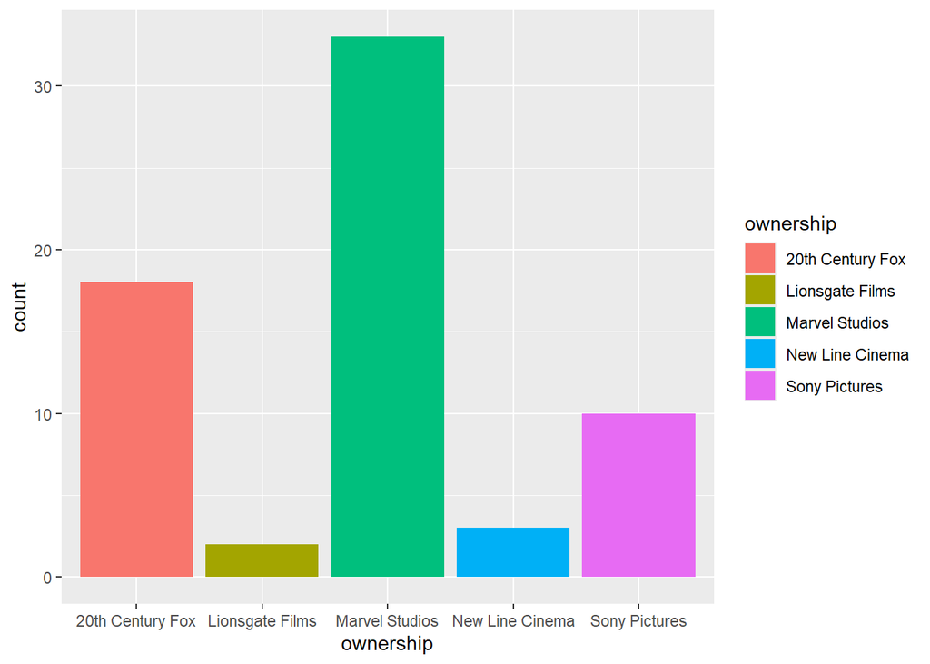

```r
marvel_data |>
  ggplot(aes(x = ownership))+
  geom_bar(aes(fill = ownership))
```

**Number of movies in each phase**

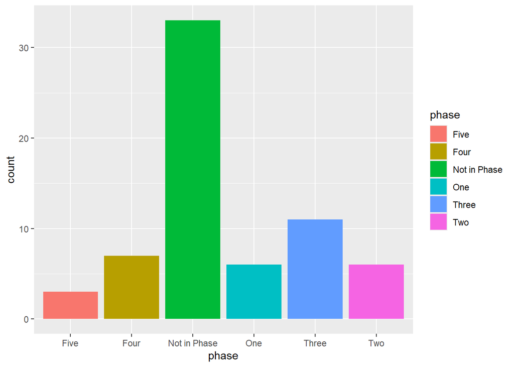

```r
ggplot(marvel_data, aes(x = phase))+
  geom_bar(aes(fill = phase))
```

**Number of movies released in each year and month**

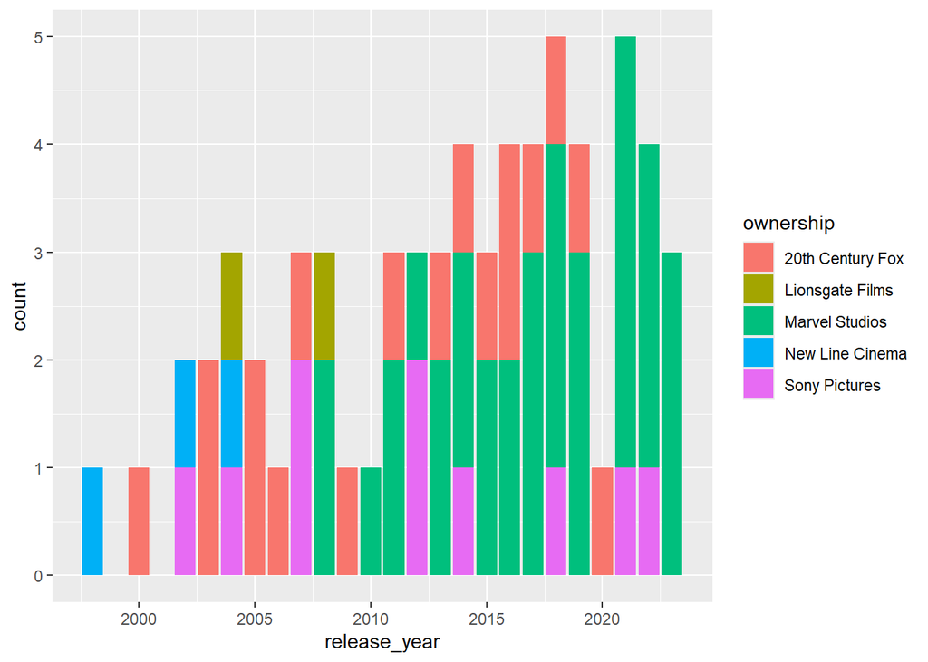

```r
marvel_data |>
  ggplot(aes(x = release_year, fill = ownership))+
  geom_bar()
```

```r
marvel_data |>
  count(release_month, sort = TRUE)
```

```
## # A tibble: 12 × 2
##    release_month     n
##    <chr>         <int>
##  1 May              19
##  2 July             11
##  3 February          6
##  4 November          6
##  5 April             5
##  6 June              5
##  7 August            4
##  8 December          3
##  9 March             3
## 10 October           2
## 11 January           1
## 12 September         1
```

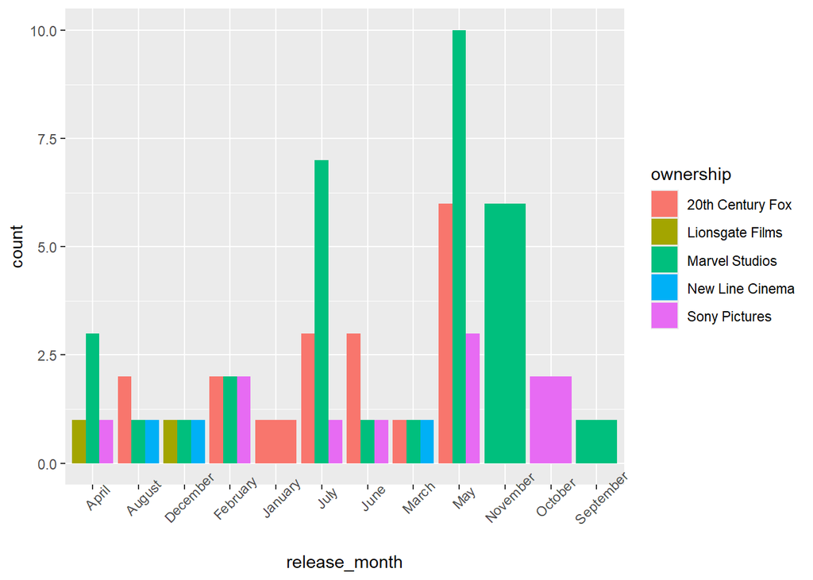

```r
marvel_data |>
  ggplot(aes(x = release_month))+
  geom_bar(aes(fill = ownership),position = "dodge")+
  theme(axis.text.x = element_text(angle = 45))
```

**Total budget and world wide box office collection for movies** **that released in each year**

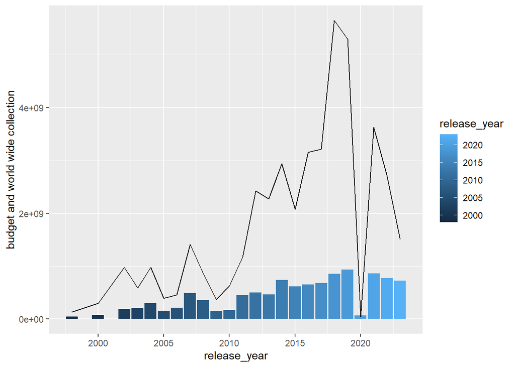

```r
marvel_data |>
  group_by(release_year)|>
  summarise(total_budget = sum(budget),
            total_collction_worldwide = sum(worldwide_box_office))|>
  ggplot(aes(x = release_year))+
  geom_col(aes(y = total_budget, fill = release_year))+
  geom_line(aes(y = total_collction_worldwide))+
  labs(y = "budget and world wide collection")
```

**relationship between budget and worldwide collection of each movies**

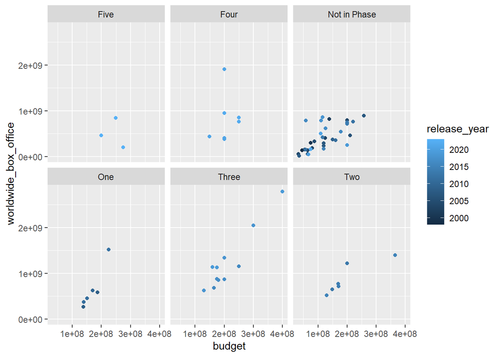

```r
 marvel_data |>
   arrange(release_year) |>
   ggplot(aes(x = budget, y = worldwide_box_office, color = release_year))+
   geom_point(position = "jitter")+
   facet_wrap(~phase)
```

**movie which have highest and lowest budget**

```r
marvel_data |>
  slice_max(budget)
```

```
## # A tibble: 1 × 23
##   movie            release_date release_month release_day release_year ownership
##   <chr>            <chr>        <chr>               <dbl>        <dbl> <chr>
## 1 Avengers: Endga… 4/26/2019    April                  26         2019 Marvel S…
## # ℹ 17 more variables: domestic_box_office <dbl>,
## #   inflation_adjusted_domestic <dbl>, international_box_office <dbl>,
## #   inflation_adjusted_international <dbl>, worldwide_box_office <dbl>,
## #   inflation_adjusted_worldwide <dbl>, opening_weekend <dbl>,
## #   inflation_adjusted_opening_weekend <dbl>, budget <dbl>,
## #   inflation_adjusted_budget <dbl>, im_db_score <dbl>, meta_score <dbl>,
## #   tomatometer <dbl>, rotten_tomato_audience_score <dbl>, …
```

```r
marvel_data |>
  slice_min(budget)
```

```
## # A tibble: 1 × 23
##   movie        release_date release_month release_day release_year ownership
##   <chr>        <chr>        <chr>               <dbl>        <dbl> <chr>
## 1 The Punisher 4/16/2004    April                  16         2004 Lionsgate Fi…
## # ℹ 17 more variables: domestic_box_office <dbl>,
## #   inflation_adjusted_domestic <dbl>, international_box_office <dbl>,
## #   inflation_adjusted_international <dbl>, worldwide_box_office <dbl>,
## #   inflation_adjusted_worldwide <dbl>, opening_weekend <dbl>,
## #   inflation_adjusted_opening_weekend <dbl>, budget <dbl>,
## #   inflation_adjusted_budget <dbl>, im_db_score <dbl>, meta_score <dbl>,
## #   tomatometer <dbl>, rotten_tomato_audience_score <dbl>, …
```

**Movies that have highest and lowest international collection in each year**

```r
marvel_max <- marvel_data |>
  group_by(release_year) |>
  slice_max(international_box_office) |>
  select(movie, release_year, international_box_office, budget)|>
  arrange(release_year)
```

```r
marvel_min <- marvel_data |>
  group_by(release_year)|>
  slice_min(international_box_office) |>
  select(movie, release_year, international_box_office, budget)
```

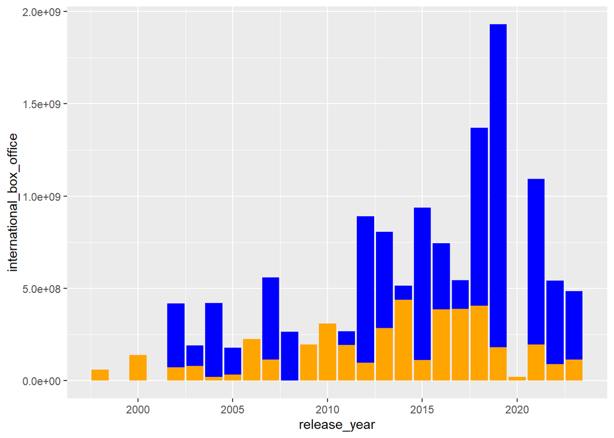

```r
ggplot()+
  geom_col(data = marvel_max,
           aes(x = release_year, y = international_box_office), fill = "blue")+
  geom_col(data = marvel_min,
           aes(x = release_year, y = international_box_office), fill = "orange")
```

**total box office collection and budget in each year**

```r
mcu_collect <- marvel_data |>
  group_by(release_year, ownership) |>
  summarise(across(c(domestic_box_office, inflation_adjusted_domestic,
              international_box_office, inflation_adjusted_international,
              worldwide_box_office, inflation_adjusted_worldwide,
              opening_weekend, inflation_adjusted_opening_weekend,
              budget, inflation_adjusted_budget),sum),
            .groups = 'drop')
```

```r
head(mcu_collect)
```

```
## # A tibble: 6 × 12
##   release_year ownership        domestic_box_office inflation_adjusted_domestic
##          <dbl> <chr>                          <dbl>                       <dbl>
## 1         1998 New Line Cinema             70141876                   157482710
## 2         2000 20th Century Fox           157299717                   307303519
## 3         2002 New Line Cinema             81676888                   148030572
## 4         2002 Sony Pictures              403706375                   731674375
## 5         2003 20th Century Fox           317493212                   554428435
## 6         2004 Lionsgate Films             33664370                    57083056
## # ℹ 8 more variables: international_box_office <dbl>,
## #   inflation_adjusted_international <dbl>, worldwide_box_office <dbl>,
## #   inflation_adjusted_worldwide <dbl>, opening_weekend <dbl>,
## #   inflation_adjusted_opening_weekend <dbl>, budget <dbl>,
## #   inflation_adjusted_budget <dbl>
```

**domestic, international, world wide and opening weekend box office collecton** **in each year for every company**

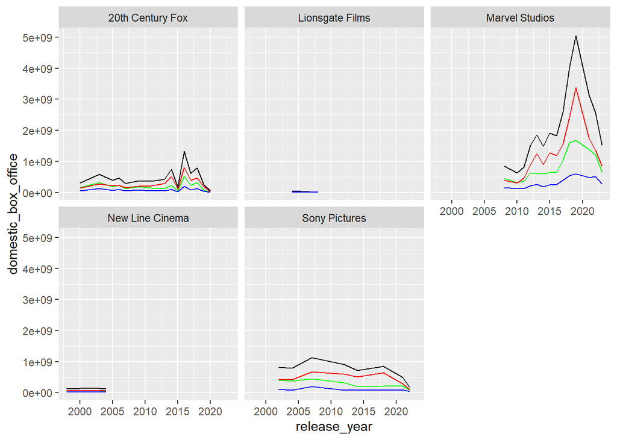

```r
mcu_collect |>
  ggplot(aes(x = release_year))+
  geom_line(aes(y = domestic_box_office),color = "green")+
  geom_line(aes(y = international_box_office), color = "red")+
  geom_line(aes(y = worldwide_box_office), color = "black")+
  geom_line(aes(y = opening_weekend), color = "blue")+
  facet_wrap(~ownership)
```

**Budget Vs imdb score**

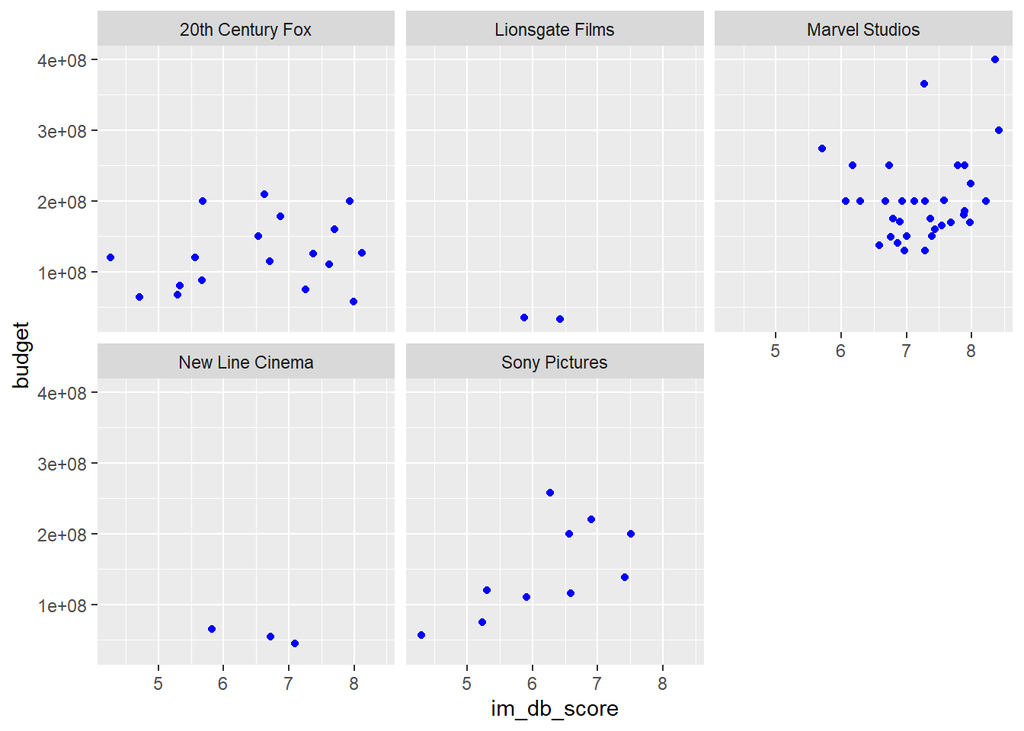

```r
 marvel_data |>
   ggplot(aes(x = im_db_score, y = budget))+
   geom_point(position = "jitter", color = "blue")+
   facet_wrap(~ownership)
```

**world wide box office collection Vs imdb score**

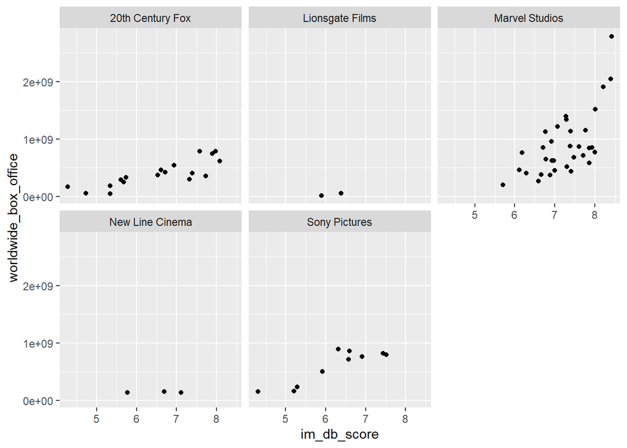

```r
marvel_data |>
   ggplot(aes(x = im_db_score, y = worldwide_box_office))+
   geom_point(position = "jitter")+
   facet_wrap(~ownership)
```

**international box office collection Vs imdb score**

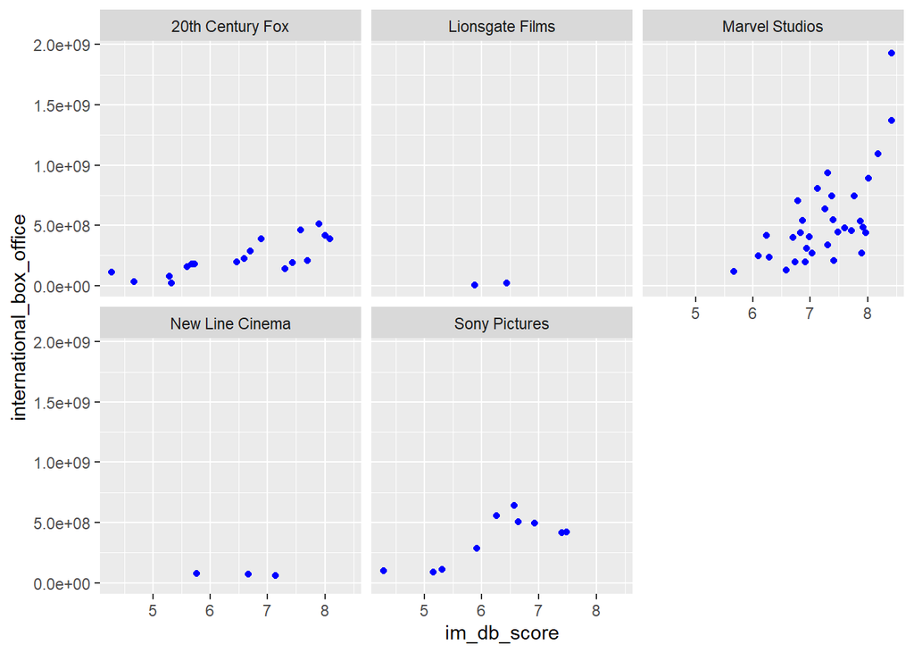

```r
marvel_data |>
   ggplot(aes(x = im_db_score, y = international_box_office))+
   geom_point(color = "blue", position = "jitter")+
   facet_wrap(~ownership)
```

**finding the mean of all ratings**

```r
imdb_mean <- mean(marvel_data$im_db_score)
meta_mean <- mean(marvel_data$meta_score)
tomato_mean <- mean(marvel_data$tomatometer)
rotten_mean <- mean(marvel_data$rotten_tomato_audience_score)
```

**movies which is higher or lower of each ratings**

```r
marvel_ratings <- marvel_data |>
   mutate(imdb_rate = ifelse(im_db_score > imdb_mean, "above_mean", "below_mean"))|>
   mutate(meta_rate = ifelse(meta_score > meta_mean, "above_mean","below_mean"))|>
   mutate(tomato_rate = ifelse(tomatometer > tomato_mean, "above_mean","below_mean"))|>
   mutate(rotten_rate = ifelse(rotten_tomato_audience_score > rotten_mean,
                               "above_mean","below_mean"))
```

```r
head(marvel_ratings)
```

```
## # A tibble: 6 × 27
##   movie            release_date release_month release_day release_year ownership
##   <chr>            <chr>        <chr>               <dbl>        <dbl> <chr>
## 1 Iron Man         05-02-2008   May                     2         2008 Marvel S…
## 2 The Incredible … 6/13/2008    June                   13         2008 Marvel S…
## 3 Iron Man 2       05-07-2010   May                     7         2010 Marvel S…
## 4 Thor             05-06-2011   May                     6         2011 Marvel S…
## 5 Captain America… 7/22/2011    July                   22         2011 Marvel S…
## 6 The Avengers     05-04-2012   May                     4         2012 Marvel S…
## # ℹ 21 more variables: domestic_box_office <dbl>,
## #   inflation_adjusted_domestic <dbl>, international_box_office <dbl>,
## #   inflation_adjusted_international <dbl>, worldwide_box_office <dbl>,
## #   inflation_adjusted_worldwide <dbl>, opening_weekend <dbl>,
## #   inflation_adjusted_opening_weekend <dbl>, budget <dbl>,
## #   inflation_adjusted_budget <dbl>, im_db_score <dbl>, meta_score <dbl>,
## #   tomatometer <dbl>, rotten_tomato_audience_score <dbl>, …
```

**Number of movies which is higher or lower than its mean ratings.**

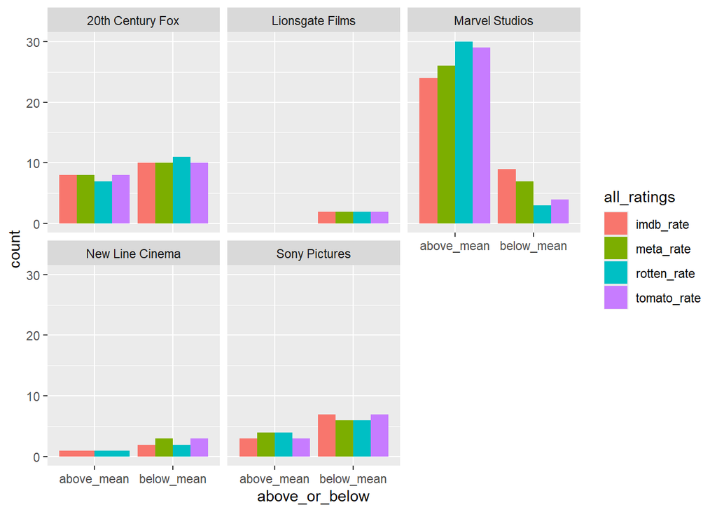

```r
marvel_ratings |>
   select(movie, release_year, ownership, imdb_rate,meta_rate, tomato_rate, rotten_rate)|>
   pivot_longer(
     cols = imdb_rate:rotten_rate,
     names_to = "all_ratings",
     values_to = "above_or_below"
   ) |>
   ggplot(aes(x = above_or_below))+
   geom_bar(aes(fill = all_ratings),position = "dodge") +
   facet_wrap(~ownership)
```

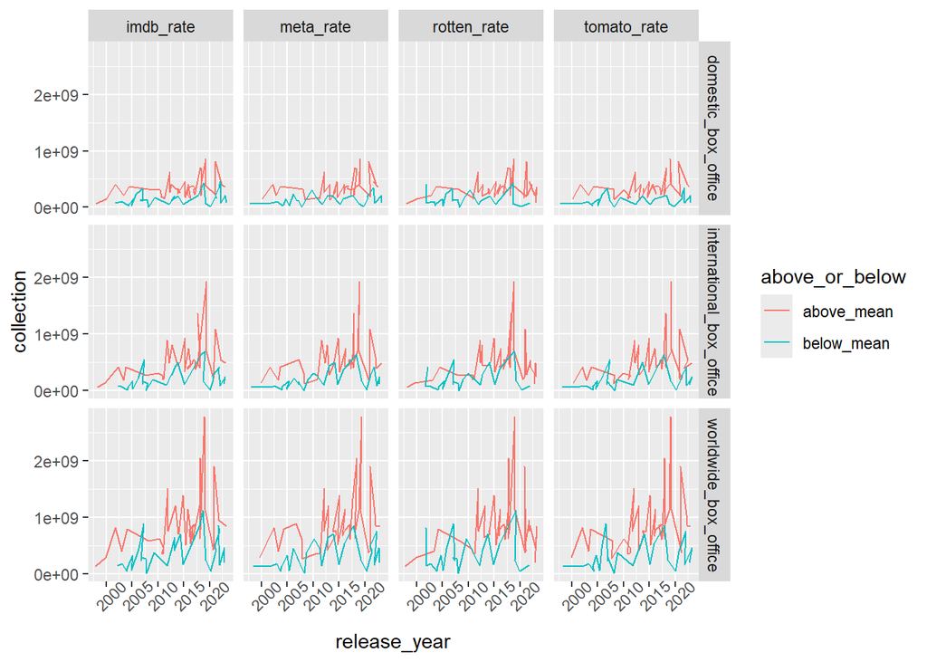

```r
marvel_ratings |>
   select(movie, release_year, ownership,ends_with("rate"),
          ends_with("box_office"))|>
   pivot_longer(
     cols = ends_with("box_office"),
     names_to = "box_office_type",
     values_to = "collection"
   ) |>
   pivot_longer(
     cols = imdb_rate:rotten_rate,
     names_to = "all_ratings",
     values_to = "above_or_below"
   )|>
   ggplot(aes(x = release_year, y = collection))+
   geom_line(aes(color = above_or_below), position = "jitter")+
   facet_grid(box_office_type~all_ratings)+
   theme(axis.text.x = element_text(angle = 45))
```